# Identificando a los Clientes del Futuro: Un Modelo Predictivo de Valor de Vida (CLV)

Gutierrez Fernandez, Jesus Osmar y Marcelo Porcayo, Tonancy Lizahaya | Especialistas del Comportamiento

Septiembre 2025

### **El Desafío: Un Presupuesto de Marketing de $10M y una Pregunta Crítica**

Una empresa líder de E-commerce se enfrentaba a un dilema: con un presupuesto de marketing de $10 millones de dólares, ¿cómo asegurarse de que cada dólar se invierte en atraer y retener a los clientes que realmente impulsarán el crecimiento a largo plazo? La estrategia de “tratar a todos por igual” estaba resultando ineficiente y costosa.

### **El Descubrimiento: El ADN del Comportamiento del Consumidor**

Analizamos el historial de transacciones de miles de clientes para descifrar su “ADN de comportamiento”, resumiéndolo en tres métricas clave (RFM): **Recencia, Frecuencia y Gasto Monetario**.

Construimos un modelo de Machine Learning (Random Forest) que, basándose en este ADN, logró predecir el valor de gasto futuro de un cliente con una **fuerza predictiva del 65%**. El modelo nos reveló en qué se fija para identificar a un futuro cliente VIP:

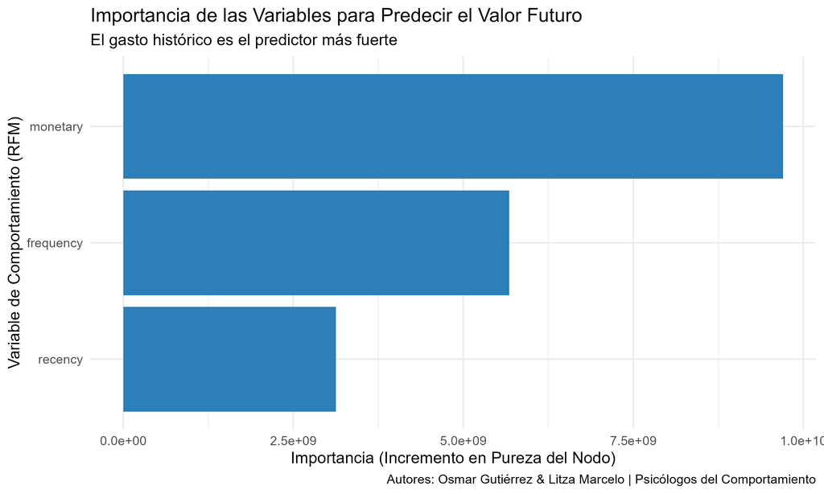

El **gasto histórico (`monetary`)** es, por mucho, el factor más poderoso. En pocas palabras: la mejor señal del gasto futuro de un cliente es su gasto pasado.

### **La Estrategia Inteligente: De la Predicción a la Inversión Focalizada**

Este modelo no es una bola de cristal, es un **sistema de priorización inteligente**. Nos permite diseñar una estrategia de 3 niveles para maximizar el ROI del presupuesto de marketing:

1. **Programa VIP (Retener a los Campeones):** Identificar al top 10% de clientes con mayor valor predicho y blindarlos con beneficios exclusivos y servicio prioritario.
2. **Campaña de “Segunda Compra” (Activar a los Ocasionales):** Enfocar campañas de bajo costo para incentivar una segunda compra en la masiva base de clientes que solo han comprado una vez.
3. **Servicio al Cliente Predictivo (Proteger el Valor):** Integrar el modelo en el sistema de soporte para dar atención de élite a los clientes con alto potencial, evitando perderlos por una mala experiencia.

Con este enfoque, “ConnecTel” puede pasar de un gasto de marketing difuso a una **inversión quirúrgica y rentable**, asegurando que los recursos se dirijan a los clientes que construirán el futuro de la empresa.